# Traitement_Analytique_Donnees_blank

### `Exercice 1`

- Joindre les tableaux du schéma relationnel en utilisant des opérations de jointure et, à partir du tableau joint répondez aux questions suivantes.
- Déterminer le nombre de stations climatologiques enregistrées dans ce tableau.
- Générer un tableau de résultats regroupés par date, nom et type de donnée présentant les valeurs minimales, maximales et moyennes par groupe. Le regroupement par date doit se faire par mois. Pour ce faire, il est impératif de changer le format de la colonne date.

### `Exercice 2`

Un bureau d'études a conçu un système relationnel pour gérer une plateforme de vente de musique numérique (similaire, mais à une échelle réduite, à iTunes ou Spotify). Ce schéma inclut des informations sur les artistes, les albums, les chansons, les clients, les employés, les factures et les listes de lecture.

Le schéma relationnel est illustré dans la figure ci-dessus

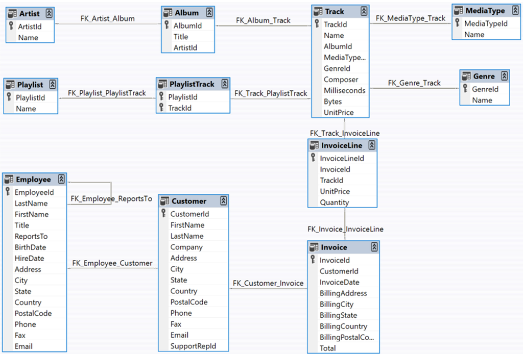

À partir de ce système relationnel, veuillez répondre aux questions suivantes :

- Utilisez les scripts du dossier chinook pour créer le schéma relationnel et peupler les tables.
- À l'aide du schéma relationnel et des fonctions de regroupement et de jointure, veuillez répondre aux questions suivantes formulées par le chef du service des ventes :
  - Quel montant les clients ont-ils dépensé par artiste
  - Quels sont les 10 genres musicaux les plus vendus?
  - Quelles sont les chansons les plus vendues (Quantité)
  - Quel est le total des ventes par répresentante de support
  - Quelles playlists contiennent les chansons Eruption et The Trooper, qui en sont les compositeurs et à quels albums appartiennent-elles